# CREDIT CARD FRAUD DETECTION

### Data science using R project

### Ashish Chander (1BM17CS148)

### Shreyank D Jain S P (1BM17CS097)

### Ravi Prakash N (1BM17CS074)

In this R Project, we will learn how to perform detection of credit cards. We will go through the Logistic Regression and Decision Trees algorithms , For carrying out the credit card fraud detection, we will make use of the Card Transactions dataset that contains a mix of fraud as well as non-fraudulent transactions.

### Importing packages and Dataset

```r
library(ranger)
library(caret)
library(data.table)
```

```r
creditcard_data <- read.csv("C:/Users/shreyank/OneDrive/Documents/DsrProject/creditcard.csv")
```

### Data Exploration

In this section of the fraud detection ML project, we will explore the data that is contained in the creditcard_data dataframe. We will proceed by displaying the creditcard_data using the head() function as well as the tail() function. We will then proceed to explore the other components of this dataframe –

Printing Dimention of dataset (i.e Number of rows and column)

```r
dim(creditcard_data)
```

1. 284807

2. 31

Printing first 6 lines of the dataset

```r
head(creditcard_data,6)
```

| Time | V1 | V2 | V3 | V4 | V5 | V6 | V7 | V8 | V9 | ... | V21 | V22 | V23 | V24 | V25 | V26 | V27 | V28 | Amount | Class |
| --- | --- | --- | --- | --- | --- | --- | --- | --- | --- | --- | --- | --- | --- | --- | --- | --- | --- | --- | --- | --- |
| 0 | -1.3598071 | -0.07278117 | 2.5363467 | 1.3781552 | -0.33832077 | 0.46238778 | 0.23959855 | 0.09869790 | 0.3637870 | ... | -0.018306778 | 0.277837576 | -0.11047391 | 0.06692807 | 0.1285394 | -0.1891148 | 0.133558377 | -0.02105305 | 149.62 | 0 |
| 0 | 1.1918571 | 0.26615071 | 0.1664801 | 0.4481541 | 0.06001765 | -0.08236081 | -0.07880298 | 0.08510165 | -0.2554251 | ... | -0.225775248 | -0.638671953 | 0.10128802 | -0.33984648 | 0.1671704 | 0.1258945 | -0.008983099 | 0.01472417 | 2.69 | 0 |
| 1 | -1.3583541 | -1.34016307 | 1.7732093 | 0.3797796 | -0.50319813 | 1.80049938 | 0.79146096 | 0.24767579 | -1.5146543 | ... | 0.247998153 | 0.771679402 | 0.90941226 | -0.68928096 | -0.3276418 | -0.1390966 | -0.055352794 | -0.05975184 | 378.66 | 0 |
| 1 | -0.9662717 | -0.18522601 | 1.7929933 | -0.8632913 | -0.01030888 | 1.24720317 | 0.23760894 | 0.37743587 | -1.3870241 | ... | -0.108300452 | 0.005273597 | -0.19032052 | -1.17557533 | 0.6473760 | -0.2219288 | 0.062722849 | 0.06145763 | 123.50 | 0 |
| 2 | -1.1582331 | 0.87773675 | 1.5487178 | 0.4030339 | -0.40719338 | 0.09592146 | 0.59294075 | -0.27053268 | 0.8177393 | ... | -0.009430697 | 0.798278495 | -0.13745808 | 0.14126698 | -0.2060096 | 0.5022922 | 0.219422230 | 0.21515315 | 69.99 | 0 |
| 2 | -0.4259659 | 0.96052304 | 1.1411093 | -0.1682521 | 0.42098688 | -0.02972755 | 0.47620095 | 0.26031433 | -0.5686714 | ... | -0.208253515 | -0.559824796 | -0.02639767 | -0.37142658 | -0.2327938 | 0.1059148 | 0.253844225 | 0.08108026 | 3.67 | 0 |

Printing last 6 lines of the dataset

```r
tail(creditcard_data,6)
```

|  | Time | V1 | V2 | V3 | V4 | V5 | V6 | V7 | V8 | V9 | ... | V21 | V22 | V23 | V24 | V25 | V26 | V27 | V28 | Amount | Class |
| --- | --- | --- | --- | --- | --- | --- | --- | --- | --- | --- | --- | --- | --- | --- | --- | --- | --- | --- | --- | --- | --- |
| 284802 | 172785 | 0.1203164 | 0.93100513 | -0.5460121 | -0.7450968 | 1.13031398 | -0.2359732 | 0.8127221 | 0.1150929 | -0.2040635 | ... | -0.3142046 | -0.8085204 | 0.05034266 | 0.102799590 | -0.4358701 | 0.1240789 | 0.217939865 | 0.06880333 | 2.69 | 0 |
| 284803 | 172786 | -11.8811179 | 10.07178497 | -9.8347835 | -2.0666557 | -5.36447278 | -2.6068373 | -4.9182154 | 7.3053340 | 1.9144283 | ... | 0.2134541 | 0.1118637 | 1.01447990 | -0.509348453 | 1.4368069 | 0.2500343 | 0.943651172 | 0.82373096 | 0.77 | 0 |
| 284804 | 172787 | -0.7327887 | -0.05508049 | 2.0350297 | -0.7385886 | 0.86822940 | 1.0584153 | 0.0243297 | 0.2948687 | 0.5848000 | ... | 0.2142053 | 0.9243836 | 0.01246304 | -1.016225669 | -0.6066240 | -0.3952551 | 0.068472470 | -0.05352739 | 24.79 | 0 |
| 284805 | 172788 | 1.9195650 | -0.30125385 | -3.2496398 | -0.5578281 | 2.63051512 | 3.0312601 | -0.2968265 | 0.7084172 | 0.4324540 | ... | 0.2320450 | 0.5782290 | -0.03750086 | 0.640133881 | 0.2657455 | -0.0873706 | 0.004454772 | -0.02656083 | 67.88 | 0 |
| 284806 | 172788 | -0.2404400 | 0.53048251 | 0.7025102 | 0.6897992 | -0.37796113 | 0.6237077 | -0.6861800 | 0.6791455 | 0.3920867 | ... | 0.2652449 | 0.8000487 | -0.16329794 | 0.123205244 | -0.5691589 | 0.5466685 | 0.108820735 | 0.10453282 | 10.00 | 0 |
| 284807 | 172792 | -0.5334125 | -0.18973334 | 0.7033374 | -0.5062712 | -0.01254568 | -0.6496167 | 1.5770063 | -0.4146504 | 0.4861795 | ... | 0.2610573 | 0.6430784 | 0.37677701 | 0.008797379 | -0.4736487 | -0.8182671 | -0.002415309 | 0.01364891 | 217.00 | 0 |

table function returns the frequency of various category

```r
table(creditcard_data$Class)
```

```
     0      1
284315    492
```

```r
summary(creditcard_data$Amount)
```

```
    Min.  1st Qu.   Median     Mean  3rd Qu.     Max.
    0.00     5.60    22.00    88.35    77.17 25691.16
```

Printing column names of the dataset

```r
names(creditcard_data)
```

1. 'Time'

2. 'V1'

3. 'V2'

4. 'V3'

5. 'V4'

6. 'V5'

7. 'V6'

8. 'V7'

9. 'V8'

10. 'V9'

11. 'V10'

12. 'V11'

13. 'V12'

14. 'V13'

15. 'V14'

16. 'V15'

17. 'V16'

18. 'V17'

19. 'V18'

20. 'V19'

21. 'V20'

22. 'V21'

23. 'V22'

24. 'V23'

25. 'V24'

26. 'V25'

27. 'V26'

28. 'V27'

29. 'V28'

30. 'Amount'

31. 'Class'

## Data manipulation

In this section of the R data science project, we will scale our data using the scale() function. We will apply this to the amount component of our creditcard_data amount. Scaling is also known as feature standardization. With the help of scaling, the data is structured according to a specified range. Therefore, there are no extreme values in our dataset that might interfere with the functioning of our model.

```r
head(creditcard_data)
```

| Time | V1 | V2 | V3 | V4 | V5 | V6 | V7 | V8 | V9 | ... | V21 | V22 | V23 | V24 | V25 | V26 | V27 | V28 | Amount | Class |
| --- | --- | --- | --- | --- | --- | --- | --- | --- | --- | --- | --- | --- | --- | --- | --- | --- | --- | --- | --- | --- |
| 0 | -1.3598071 | -0.07278117 | 2.5363467 | 1.3781552 | -0.33832077 | 0.46238778 | 0.23959855 | 0.09869790 | 0.3637870 | ... | -0.018306778 | 0.277837576 | -0.11047391 | 0.06692807 | 0.1285394 | -0.1891148 | 0.133558377 | -0.02105305 | 149.62 | 0 |
| 0 | 1.1918571 | 0.26615071 | 0.1664801 | 0.4481541 | 0.06001765 | -0.08236081 | -0.07880298 | 0.08510165 | -0.2554251 | ... | -0.225775248 | -0.638671953 | 0.10128802 | -0.33984648 | 0.1671704 | 0.1258945 | -0.008983099 | 0.01472417 | 2.69 | 0 |
| 1 | -1.3583541 | -1.34016307 | 1.7732093 | 0.3797796 | -0.50319813 | 1.80049938 | 0.79146096 | 0.24767579 | -1.5146543 | ... | 0.247998153 | 0.771679402 | 0.90941226 | -0.68928096 | -0.3276418 | -0.1390966 | -0.055352794 | -0.05975184 | 378.66 | 0 |
| 1 | -0.9662717 | -0.18522601 | 1.7929933 | -0.8632913 | -0.01030888 | 1.24720317 | 0.23760894 | 0.37743587 | -1.3870241 | ... | -0.108300452 | 0.005273597 | -0.19032052 | -1.17557533 | 0.6473760 | -0.2219288 | 0.062722849 | 0.06145763 | 123.50 | 0 |
| 2 | -1.1582331 | 0.87773675 | 1.5487178 | 0.4030339 | -0.40719338 | 0.09592146 | 0.59294075 | -0.27053268 | 0.8177393 | ... | -0.009430697 | 0.798278495 | -0.13745808 | 0.14126698 | -0.2060096 | 0.5022922 | 0.219422230 | 0.21515315 | 69.99 | 0 |
| 2 | -0.4259659 | 0.96052304 | 1.1411093 | -0.1682521 | 0.42098688 | -0.02972755 | 0.47620095 | 0.26031433 | -0.5686714 | ... | -0.208253515 | -0.559824796 | -0.02639767 | -0.37142658 | -0.2327938 | 0.1059148 | 0.253844225 | 0.08108026 | 3.67 | 0 |

```r
creditcard_data$Amount=scale(creditcard_data$Amount)
NewData=creditcard_data[,-c(1)]
head(NewData)
```

| V1 | V2 | V3 | V4 | V5 | V6 | V7 | V8 | V9 | V10 | ... | V21 | V22 | V23 | V24 | V25 | V26 | V27 | V28 | Amount | Class |
| --- | --- | --- | --- | --- | --- | --- | --- | --- | --- | --- | --- | --- | --- | --- | --- | --- | --- | --- | --- | --- |
| -1.3598071 | -0.07278117 | 2.5363467 | 1.3781552 | -0.33832077 | 0.46238778 | 0.23959855 | 0.09869790 | 0.3637870 | 0.09079417 | ... | -0.018306778 | 0.277837576 | -0.11047391 | 0.06692807 | 0.1285394 | -0.1891148 | 0.133558377 | -0.02105305 | 0.24496383 | 0 |
| 1.1918571 | 0.26615071 | 0.1664801 | 0.4481541 | 0.06001765 | -0.08236081 | -0.07880298 | 0.08510165 | -0.2554251 | -0.16697441 | ... | -0.225775248 | -0.638671953 | 0.10128802 | -0.33984648 | 0.1671704 | 0.1258945 | -0.008983099 | 0.01472417 | -0.34247394 | 0 |
| -1.3583541 | -1.34016307 | 1.7732093 | 0.3797796 | -0.50319813 | 1.80049938 | 0.79146096 | 0.24767579 | -1.5146543 | 0.20764287 | ... | 0.247998153 | 0.771679402 | 0.90941226 | -0.68928096 | -0.3276418 | -0.1390966 | -0.055352794 | -0.05975184 | 1.16068389 | 0 |
| -0.9662717 | -0.18522601 | 1.7929933 | -0.8632913 | -0.01030888 | 1.24720317 | 0.23760894 | 0.37743587 | -1.3870241 | -0.05495192 | ... | -0.108300452 | 0.005273597 | -0.19032052 | -1.17557533 | 0.6473760 | -0.2219288 | 0.062722849 | 0.06145763 | 0.14053401 | 0 |
| -1.1582331 | 0.87773675 | 1.5487178 | 0.4030339 | -0.40719338 | 0.09592146 | 0.59294075 | -0.27053268 | 0.8177393 | 0.75307443 | ... | -0.009430697 | 0.798278495 | -0.13745808 | 0.14126698 | -0.2060096 | 0.5022922 | 0.219422230 | 0.21515315 | -0.07340321 | 0 |
| -0.4259659 | 0.96052304 | 1.1411093 | -0.1682521 | 0.42098688 | -0.02972755 | 0.47620095 | 0.26031433 | -0.5686714 | -0.37140720 | ... | -0.208253515 | -0.559824796 | -0.02639767 | -0.37142658 | -0.2327938 | 0.1059148 | 0.253844225 | 0.08108026 | -0.33855582 | 0 |

### Data Modelling

```r
library(caTools)
set.seed(123)
data_sample = sample.split(NewData$Class,SplitRatio=0.80)
train_data = subset(NewData,data_sample==TRUE)
test_data = subset(NewData,data_sample==FALSE)
```

Dimention of train data

```r
dim(train_data)
```

1. 227846

2. 30

Dimention of test data

```r
dim(test_data)
```

1. 56961

2. 30

## Fitting Logistic Regression Model

In this section of credit card fraud detection project, we will fit our first model. We will begin with logistic regression. A logistic regression is used for modeling the outcome probability of a class such as pass/fail, positive/negative and in our case – fraud/not fraud.

```r
Logistic_Model=glm(Class~.,train_data,family=binomial())
summary(Logistic_Model)
```

```
Call:
glm(formula = Class ~ ., family = binomial(), data = train_data)

Deviance Residuals:
    Min       1Q   Median       3Q      Max
-4.6108  -0.0292  -0.0194  -0.0125   4.6021

Coefficients:
             Estimate Std. Error z value Pr(>|z|)
(Intercept) -8.651305   0.160212 -53.999  < 2e-16 ***
V1           0.072540   0.044144   1.643 0.100332
V2           0.014818   0.059777   0.248 0.804220
V3           0.026109   0.049776   0.525 0.599906
V4           0.681286   0.078071   8.726  < 2e-16 ***
V5           0.087938   0.071553   1.229 0.219079
V6          -0.148083   0.085192  -1.738 0.082170 .
V7          -0.117344   0.068940  -1.702 0.088731 .
V8          -0.146045   0.035667  -4.095 4.23e-05 ***
V9          -0.339828   0.117595  -2.890 0.003855 **
V10         -0.785462   0.098486  -7.975 1.52e-15 ***
V11          0.001492   0.085147   0.018 0.986018
V12          0.087106   0.094869   0.918 0.358532
V13         -0.343792   0.092381  -3.721 0.000198 ***
V14         -0.526828   0.067084  -7.853 4.05e-15 ***
V15         -0.095471   0.094037  -1.015 0.309991
V16         -0.130225   0.138629  -0.939 0.347537
V17          0.032463   0.074471   0.436 0.662900
V18         -0.100964   0.140985  -0.716 0.473909
V19          0.083711   0.105134   0.796 0.425897
V20         -0.463946   0.081871  -5.667 1.46e-08 ***
V21          0.381206   0.065880   5.786 7.19e-09 ***
V22          0.610874   0.142086   4.299 1.71e-05 ***
V23         -0.071406   0.058799  -1.214 0.224589
V24          0.255791   0.170568   1.500 0.133706
V25         -0.073955   0.142634  -0.519 0.604109
V26          0.120841   0.202553   0.597 0.550783
V27         -0.852018   0.118391  -7.197 6.17e-13 ***
V28         -0.323854   0.090075  -3.595 0.000324 ***
Amount       0.292477   0.092075   3.177 0.001491 **
---
Signif. codes:  0 '***' 0.001 '**' 0.01 '*' 0.05 '.' 0.1 ' ' 1

(Dispersion parameter for binomial family taken to be 1)

    Null deviance: 5799.1  on 227845  degrees of freedom
Residual deviance: 1790.9  on 227816  degrees of freedom
AIC: 1850.9

Number of Fisher Scoring iterations: 12
```

After we have summarised our model, we will visual it through the following plots

### Plotting the graphs

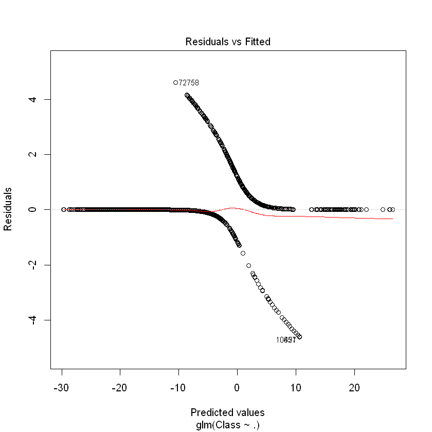

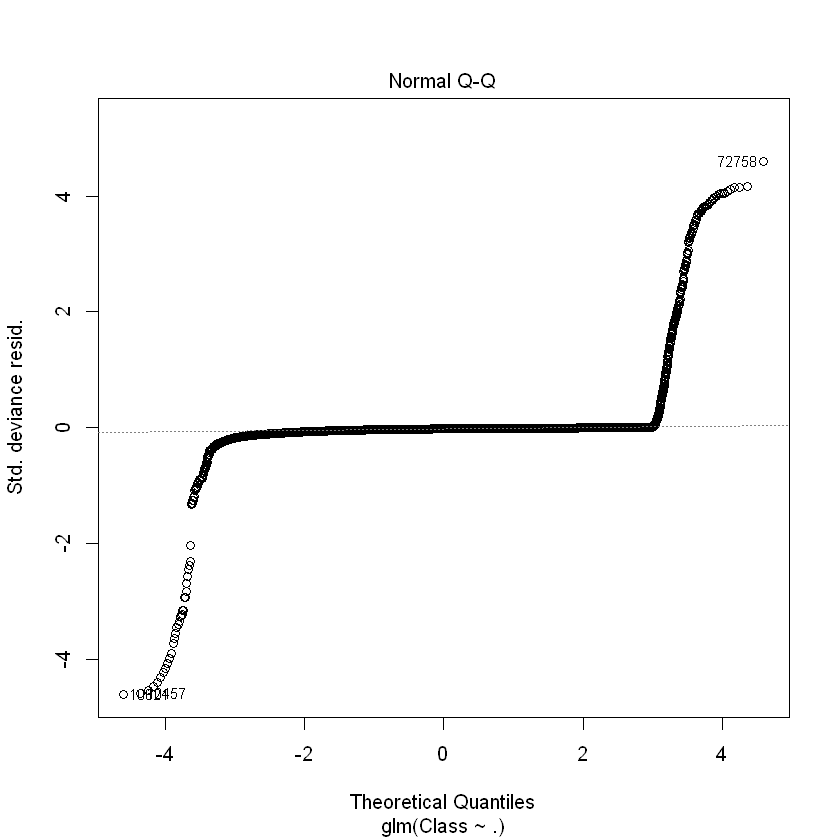

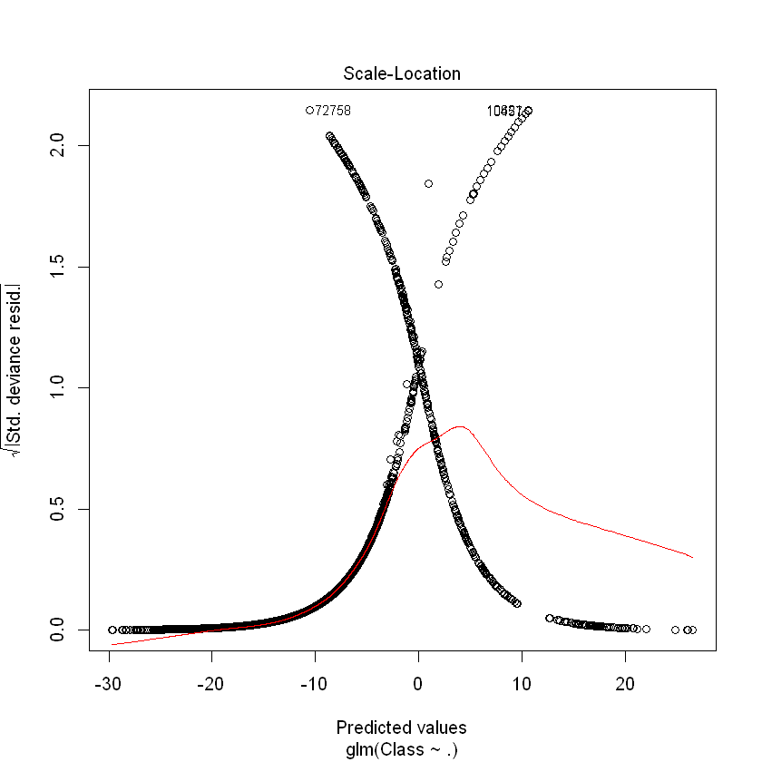

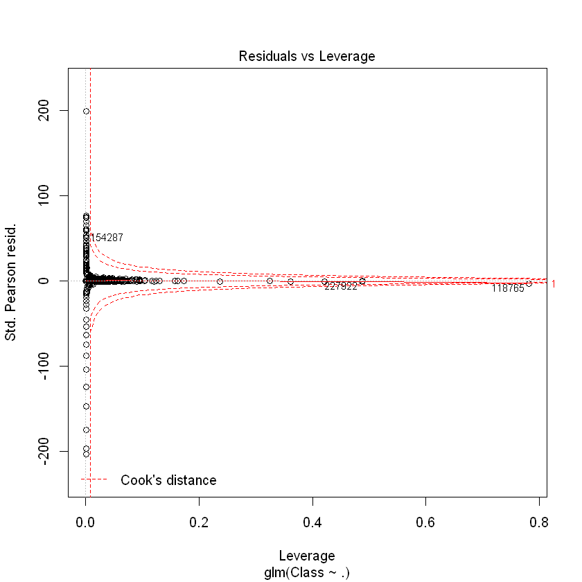

```r
plot(Logistic_Model)
```

```r
Logistic_Model=glm(Class~.,test_data,family=binomial())
summary(Logistic_Model)
```

```
Call:
glm(formula = Class ~ ., family = binomial(), data = test_data)

Deviance Residuals:
    Min       1Q   Median       3Q      Max
-4.9019  -0.0254  -0.0156  -0.0078   4.0877

Coefficients:
             Estimate Std. Error z value Pr(>|z|)
(Intercept) -12.52800   10.30537  -1.216   0.2241
V1           -0.17299    1.27381  -0.136   0.8920
V2            1.44512    4.23062   0.342   0.7327
V3            0.17897    0.24058   0.744   0.4569
V4            3.13593    7.17768   0.437   0.6622
V5            1.49014    3.80369   0.392   0.6952
V6           -0.12428    0.22202  -0.560   0.5756
V7            1.40903    4.22644   0.333   0.7388
V8           -0.35254    0.17462  -2.019   0.0435 *
V9            3.02176    8.67262   0.348   0.7275
V10          -2.89571    6.62383  -0.437   0.6620
V11          -0.09769    0.28270  -0.346   0.7297
V12           1.97992    6.56699   0.301   0.7630
V13          -0.71674    1.25649  -0.570   0.5684
V14           0.19316    3.28868   0.059   0.9532
V15           1.03868    2.89256   0.359   0.7195
V16          -2.98194    7.11391  -0.419   0.6751
V17          -1.81809    4.99764  -0.364   0.7160
V18           2.74772    8.13188   0.338   0.7354
V19          -1.63246    4.77228  -0.342   0.7323
V20          -0.69925    1.15114  -0.607   0.5436
V21          -0.45082    1.99182  -0.226   0.8209
V22          -1.40395    5.18980  -0.271   0.7868
V23           0.19026    0.61195   0.311   0.7559
V24          -0.12889    0.44701  -0.288   0.7731
V25          -0.57835    1.94988  -0.297   0.7668
V26           2.65938    9.34957   0.284   0.7761
V27          -0.45396    0.81502  -0.557   0.5775
V28          -0.06639    0.35730  -0.186   0.8526
Amount        0.22576    0.71892   0.314   0.7535
---
Signif. codes:  0 '***' 0.001 '**' 0.01 '*' 0.05 '.' 0.1 ' ' 1

(Dispersion parameter for binomial family taken to be 1)

    Null deviance: 1443.40  on 56960  degrees of freedom
Residual deviance:  378.59  on 56931  degrees of freedom
AIC: 438.59

Number of Fisher Scoring iterations: 17
```

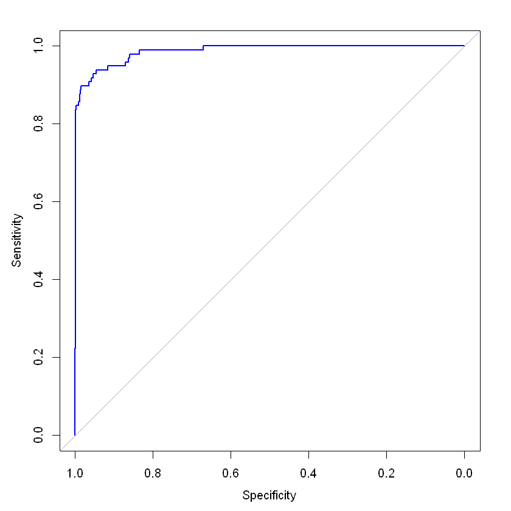

```r
library(pROC)
lr.predict <- predict(Logistic_Model,test_data, probability = TRUE)
auc.gbm = roc(test_data$Class, lr.predict, plot = TRUE, col = "blue")
```

```r
print(auc.gbm)
```

```
Call:
roc.default(response = test_data$Class, predictor = lr.predict,     plot = TRUE, col = "blue")

Data: lr.predict in 56863 controls (test_data$Class 0) < 98 cases (test_data$Class 1).
Area under the curve: 0.9875
```

## Fitting a Decision Tree Model

In this section, we will implement a decision tree algorithm. Decision Trees to plot the outcomes of a decision. These outcomes are basically a consequence through which we can conclude as to what class the object belongs to. We will now implement our decision tree model and will plot it using the rpart.plot() function. We will specifically use the recursive parting to plot the decision tree.

Loading required package

```r
library(rpart)
library(rpart.plot)
```

```r
data <- read.csv("C:/Users/shreyank/OneDrive/Documents/DsrProject/creditcard.csv")
```

```r
trainIndex  <- sample(1:nrow(data), 0.8 * nrow(data))
train <- data[trainIndex,]
test <- data[-trainIndex,]
```

```r
decisionTree_model <- rpart(Class ~ . , creditcard_data, method = 'class')
predicted_val <- predict(decisionTree_model, creditcard_data, type = 'class')
probability <- predict(decisionTree_model, creditcard_data, type = 'prob')
```

```r
print(predicted_val)
```

[output not shown]

[output cut: 15373 more lines]

### Plotting the graph

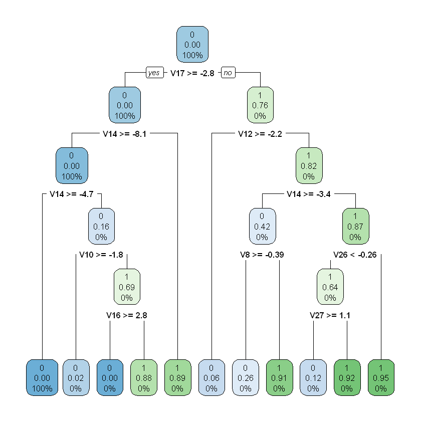

```r
rpart.plot(decisionTree_model)
```

```r
tree = rpart(Class~., data = train, method = 'class')
y_pred = predict(tree,test,type="class")
y = test['Class']

confMat <- table(test$Class,t_pred)
confMat
accuracy <- sum(diag(confMat))/sum(confMat)
accuracy
```

[output not shown]

### Classifying data using Support Vector Machines

Support vector machine(SVM) are supervised learning models with associated learning algorithms that analyze data used for classification and regression analysis. It is mostly used in classification problems. In this algorithm, each data item is plotted as a point in n-dimensional space (where n is number of features), with the value of each feature being the value of a particular coordinate. Then, classification is performed by finding the hyper-plane that best differentiates the two classes.

```r
library(ranger)
library(caret)
library(data.table)
```

```r
creditcard_data <- read.csv("C:/Users/shreyank/OneDrive/Documents/DsrProject/creditcard.csv")
creditcard_data <-creditcard_data[1:50000,]
```

```r
library(caTools)
```

```r
creditcard_data$Class <- factor(creditcard_data$Class)
NewData=creditcard_data[,-c(1)]
data_sample = sample.split(NewData$Class,SplitRatio=0.80)
train_data = subset(NewData,data_sample==TRUE)
test_data = subset(NewData,data_sample==FALSE)
```

```r
library(e1071)
svm.model <- svm(Class ~ ., data = train_data, kernel = "radial", cost = 1, gamma = 0.1)
svm.predict <- predict(svm.model,test_data)
confusionMatrix(test_data$Class, svm.predict)
```

```
Confusion Matrix and Statistics

          Reference
Prediction    0    1
         0 9970    0
         1   21    9

               Accuracy : 0.9979
                 95% CI : (0.9968, 0.9987)
    No Information Rate : 0.9991
    P-Value [Acc > NIR] : 0.9998

                  Kappa : 0.4608

 Mcnemar's Test P-Value : 1.275e-05

            Sensitivity : 0.9979
            Specificity : 1.0000
         Pos Pred Value : 1.0000
         Neg Pred Value : 0.3000
             Prevalence : 0.9991
         Detection Rate : 0.9970
   Detection Prevalence : 0.9970
      Balanced Accuracy : 0.9989

       'Positive' Class : 0
```

```r
confmatrix<-table(test_data$Class, svm.predict)
confmatrix
```

```
   svm.predict
       0    1
  0 9970    0
  1   21    9
```

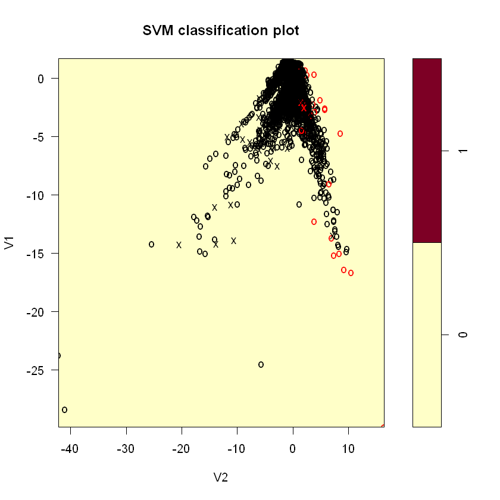

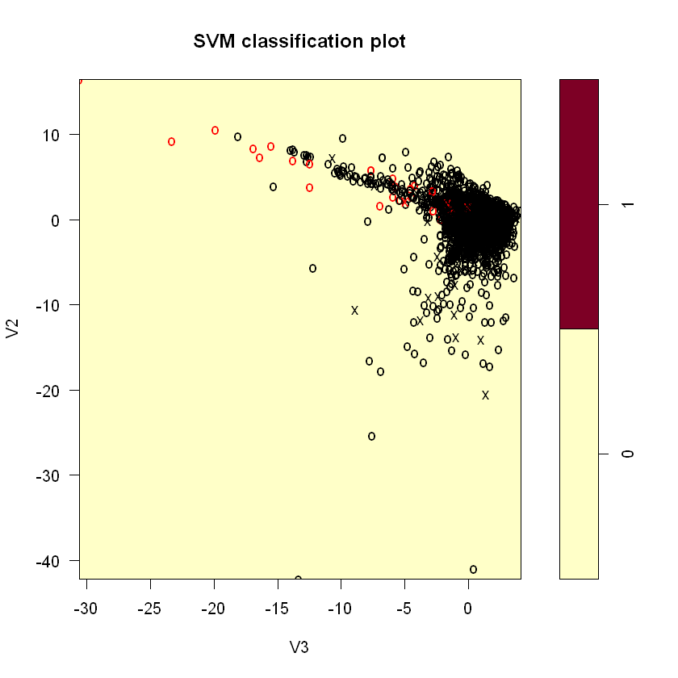

```r
plot(svm.model,data=test_data,V1~V2)
plot(svm.model,data=test_data,V2~V3)
```